# DATA 607 Assignment 3B

```r
# We are going to ignore data for the when the Borough is unspecified.

rats_BK <- filter(ratsnyc, Borough == "MANHATTAN") %>%count(CREATED_DATE3)
rats_MH <- filter(ratsnyc, Borough == "BROOKLYN") %>% count(CREATED_DATE3)
rats_BX <- filter(ratsnyc, Borough == "BRONX") %>%  count(CREATED_DATE3)
rats_SI <- filter(ratsnyc, Borough == "STATEN ISLAND") %>% count(CREATED_DATE3)
rats_QN <- filter(ratsnyc, Borough == "QUEENS") %>% count(CREATED_DATE3)

# Now we have 5 data frames for each borough

rats_BK %>% summarise(
  mean_BK = mean(n),
)
```

| mean_BK |
| --- |
| 9.613702 |

| mean_BK <dbl> |  |  |  |  |
| --- | --- | --- | --- | --- |
| 9.613702 |  |  |  |  |

1 row

```r
rats_MH %>% summarise(
  mean_MH = mean(n),
)
```

| mean_MH |
| --- |
| 12.38286 |

| mean_MH <dbl> |  |  |  |  |
| --- | --- | --- | --- | --- |
| 12.38286 |  |  |  |  |

1 row

```r
rats_BX %>% summarise(
  mean_BX = mean(n),
)
```

| mean_BX |
| --- |
| 7.480491 |

| mean_BX <dbl> |  |  |  |  |
| --- | --- | --- | --- | --- |
| 7.480491 |  |  |  |  |

1 row

```r
rats_SI %>% summarise(
  mean_SI = mean(n),
)
```

| mean_SI |
| --- |
| 2.466165 |

| mean_SI <dbl> |  |  |  |  |
| --- | --- | --- | --- | --- |
| 2.466165 |  |  |  |  |

1 row

```r
rats_QN %>% summarise(
  mean_QN = mean(n),
)
```

| mean_QN |
| --- |
| 5.540965 |

| mean_QN <dbl> |  |  |  |  |
| --- | --- | --- | --- | --- |
| 5.540965 |  |  |  |  |

1 row

```r
# Means are 9.6, 12.4, 7.5, 2.5, 5.5

rats_BK <- rats_BK %>% mutate(rm_rats_BK = rollmean(n, 6, fill = NA, align = "left"))

rats_MH <- rats_MH %>% mutate(rm_rats_MH = rollmean(n, 6, fill = NA, align = "left"))

rats_BX <- rats_BX %>% mutate(rm_rats_BX = rollmean(n, 6, fill = NA, align = "left"))

rats_SI <- rats_SI %>% mutate(rm_rats_SI = rollmean(n, 6, fill = NA, align = "left"))

rats_QN <- rats_QN %>% mutate(rm_rats_QN = rollmean(n, 6, fill = NA, align = "left"))

#Time to create a new dataframe for plotting.

# Let's find the last date in the original dataset.

ratsnyc %>% summarise(
  max_date = max(CREATED_DATE3),
)
```

| max_date |
| --- |
| 2017-09-16 |

| max_date <dttm> |  |  |  |  |
| --- | --- | --- | --- | --- |
| 2017-09-16 |  |  |  |  |

1 row

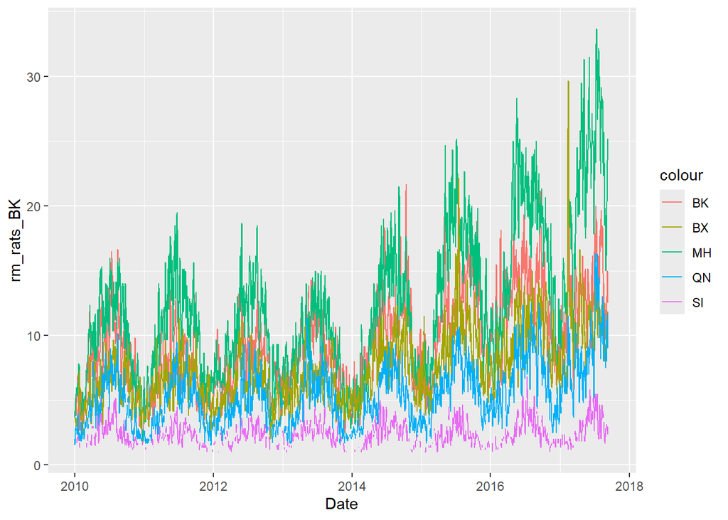

```r
# Data ends September 16 2017, let's map until the 17th

# AI Usage Citation. ChatGPT model GPT-5.5, accessed to prompt ChatGPT how to join multiple data frames when the data range was a <dttm> value across the first column across a specified time period.

rats_total <- data.frame(
  Date = seq(
    from = as.Date("2010-01-01"),
    to = as.Date("2017-09-17"),
    by = "day"
  )
)

rats_total <- rats_total %>%
  left_join(
    rats_BK %>% select(CREATED_DATE3, rm_rats_BK),
    by = c("Date" = "CREATED_DATE3")
  ) %>%
  left_join(
    rats_MH %>% select(CREATED_DATE3, rm_rats_MH),
    by = c("Date" = "CREATED_DATE3")
  ) %>%
  left_join(
    rats_BX %>% select(CREATED_DATE3, rm_rats_BX),
    by = c("Date" = "CREATED_DATE3")
  ) %>%
  left_join(
    rats_SI %>% select(CREATED_DATE3, rm_rats_SI),
    by = c("Date" = "CREATED_DATE3")
  ) %>%
  left_join(
    rats_QN %>% select(CREATED_DATE3, rm_rats_QN),
    by = c("Date" = "CREATED_DATE3")
  )

# Now there is a dataframe combining the 6 day rolling mean of the rat population across the five boroughs.

# Let's plot the rolling mean of all five boroughs

ggplot(rats_total, aes(x = Date)) +
  geom_line(aes(y = rm_rats_BK, color = "BK")) +
  geom_line(aes(y = rm_rats_MH, color = "MH")) +
  geom_line(aes(y = rm_rats_BX, color = "BX")) +
  geom_line(aes(y = rm_rats_SI, color = "SI")) +
  geom_line(aes(y = rm_rats_QN, color = "QN"))
```

# ——————————————————– # —- CONCLUSION —- # ——————————————————–

This assignment was a good challenge.

The mean for all of NYC rat sightings reported was 36.2 rat sightings per day reported with clear peaks in the summer and clear troughs in the winter.

A good follow up to this exercise would be to find out why the reported sightings were increasing from 2010 to 2017. It appears the increase exists across all boroughs except Staten Island.

If I were to redo the graph showing the data superimposed for the rolling average for each of the five boroughs, I would continue iterating the time period for the rolling average. I think a rolling average of 15 days, for example, woudl look cleaner in the final plot and make it easier to distinguish between each of the five boroughs.

# ——————————————————–

# ——————————————————–

https://uc-r.github.io/ts_moving_averages

https://www.rdocumentation.org/packages/zoo/versions/1.9-0/topics/rollmean

R for Data Science (2e) - Chapter 17

https://lubridate.tidyverse.org/reference/round_date.html

https://readr.tidyverse.org/reference/parse_datetime.html

https://lubridate.tidyverse.org/articles/lubridate.html#setting-and-extracting-information